# *Optional* - Pointers

These *optional* notes provide you with a concise introduction to *pointers* in C/C++. These notes are provided for two reasons. First, for completeness since you may come across the term pointer so it serves to demystify them. Second, pointers are an important low-level programming concept which underpins the implementation of lots of other high-level functionality. In essence we use them without really knowing.

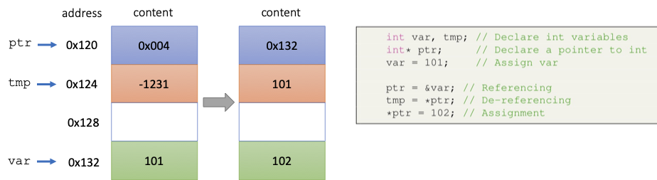

Figure 1: A simple example of referencing, de-referencing and assignment using a pointer.

## What are Pointers?

Recall that in most programming languages a variable is some information stored in a memory space used by a program. typically called its *stack*. So far, we considered the information itself, namely the *value* of the variable. We can also consider *where* the information is stored, namely the *address* of the variable. Viewing the random access memory (RAM) as a set of boxes then the value is the contents of the box, while the address is the location of the box. In C/C++ there are special variables called *pointers* whose purpose is to store addresses of other variables. When first encountered the concept of pointers can be confusing, however they are extremely important and will be needed for any serious computation.

Like variables, pointers must be declared. They point to variables of a specific type, for example `int` or `float`. Declarations of pointers start involve an asterisk attached either to the from of the pointers name as `<type> *<p_name>`, or to the end of the type as `<type>* <p_name>`, for example:

```cpp
int *pointer1; // A style preferred by C programmers emphasising expressions
int* pointer2; // A style preferred by C++ programmers emphasising types
```

Both are completely legal forms[^1]. It is a matter of taste which you use, but be careful using the C++ style when declaring multiple pointers:

```cpp
int *pointer1, *pointer2; // Declares two pointers to int
int* pointer1, pointer2; // Declares pointer1 as a pointer, but pointer2 is int!
```

If you use the C++ style then declare pointers one at a time.

There are three basic usages of pointers:

1. **Referencing** - We can access the memory address of any variable using the `&` symbol in front of the variable name. This is called *referencing* the variable and we can read `&` as being the “get the address of" operation. Hence `myPointer = &myVariable;` assigns the address of the variable to a pointer.
2. **De-referencing** - To access the value stored at an address in a pointer we use the symbol in front of the name of the pointer. This is called *de-referencing* the pointer and we can read in this context as being the “get the value at the address" operation[^2]. Hence `newVariable = *myPointer;` gets the value stored at that address stored in the pointer and assigns it to the new variable.
3. **Assignment** - De-referencing not only gets the value at an address it can also change it. For example, suppose we has declared `int* myPointer;` then `myPointer = 12;` stores the value 12 at the address pointed to by `myPointer`. We can also use `myPointer = (*myPointer) + 2;` which increments the value at the address by 2. In fact, you can use `(*myPointer)` in expressions identically to how you would use a variable of the same type[^3].

These usages are illustrated in Figure 1 and also clarified in the following simple example:

```cpp
int main()
{
    int firstVar, secondVar;
    int* ptr; // Declare a pointer to int
    firstVar = 5;
    secondVar = 2;

    ptr = &firstVar; // Store the address of the first variable in ptr
    (*ptr)++; // Increment the value that ptr points to
    secondVar = *ptr; // Set the second variable to the value pointed to by ptr
    // Both firstVar and secondVar now have the value 6

    return 0;
}
```

Even if you have not encountered pointers before you have almost certainly used them without knowing, e.g. they are implicit in `Python`. There are (at least) four primary uses of pointers:

- Passing a variable by *reference* rather than *value*  
  This will be discussed more next week when we will look at *functions*. Pointers provide a means for a function to modify their inputs.
- Passing large amounts of data  
  If a large quantity of data (like an array) needs to be passed to a function it is much more efficient to send the address of the data than copy across the entire set of data itself.
- Handling more complex data  
  Pointers enable sophisticated data structures to be created liked linked-lists and arrays of structures.
- Dynamical memory allocation  
  We have seen that arrays in C/C++ have a fixed size at compile-time, but we can have arrays with a size that is determined in run-time by using pointers and dynamical memory allocation (see shortly).

We will consider the first three in more detail next week. Here we will focus on the last point by first expanding on the relation between pointers and arrays.

## Pointer arithmetic

Suppose that `myPointer` stores the address of a variable `myVariable`. We know that `myPointer` gives the value of the variable, and that `(*myPointer)+1;` adds 1 to the value of the variable. So what is `myPointer+1;` where no de-referencing is used? Answer: it increments the pointer to the adjacent block of memory that could store a variable of its type. Specifically, memory is address in bytes so `myPointer+1;` increments the address stored by `sizeof(<type>)` bytes. This kind of arithmetic works with any integer value so `myPointer-1;` decrements to the block to the one before, while declaring an integer variable `int i = 10;` and using `myPointer+i;` increments 10 blocks ahead.

Note, however, that we should never use pointer arithmetic like this for a pointer assign to the address of single variable. Why? Because, we have no guarantee the next block of memory pointed to by `myPointer+1;` is actually another valid variable of the same type in our program. For example, we could be addressing an `int` and increment to the next 4 bytes in the memory which might be storing a `double`. In this case we will wrongly interpret half of the `double`’s 8 bytes as an `int`. In other words we get junk, as shown in Figure 2. The usefulness of pointer arithmetic only becomes clear when we know a sequence of contiguous variables of one type are stored in the memory, for example in an array.

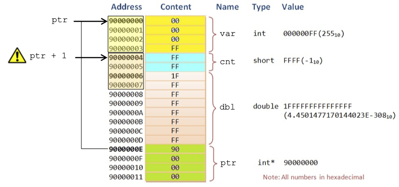

Figure 2: An example of a programs memory with `int`, `short` and `double` variables stored, along with an `int*` pointer `ptr` pointing at the `int` variable. Pointer arithmetic on `ptr` indexes across the memory in 4 byte chunks corresponding to its type. In this case `ptr + 1` points at a block of memory spanning the `short` and `double` variable, so will return junk.

## Arrays and pointers

When you declare an array, such as `float arr[5];`, the array name `arr` is actually a pointer to the memory location for the first element of the array, so formally for this 1D array `arr` and `&arr[0]` are the equivalent. This means we can access elements of the array using either the index notation, e.g. `arr[3]`, or via pointer arithmetic and de-referencing, e.g. `(arr + 3)`. This works both ways. So given a pointer `ptr` we can also access block beyond it by using index notation, so `ptr[2]` is equivalent to `(ptr + 2)`. The following example illustrates these points:

```cpp
#include <iostream>

int main()
{
  static const int num = 3; // Number of values
  float vals[] = {3.14,2.71,6.28};
  float *ptr;

  ptr = vals; // Point to start of array, equivalent to ptr = &vals[0];

  for(unsigned int i=0;i<num;i++)
  {
    std::cout << *(vals + i) << " squared is "; // Pointer arithmetic same as vals[i]
    *(ptr+i) = *(ptr+i) * *(ptr+i); // Square an update the value in vals[i].
    std::cout << ptr[i] << "\n"; // Access what ptr points to using index notation
  }
}
```

Line 14 here provides an example of pointer de-referencing and multiplication all in the same expression[^4]. What happens if you set `num = 20`? Your code will compile because C/C++ does not check whether your code violates the bounds of an array. One of two things will happen when you run it. Your code will run and exit normally, but display lots of junk values beyond the 3 expected ones. Or your code will abort abnormally and may display a dreaded `segmentation fault` error.

Naturally the next question is how are multi-dimensional arrays related to pointers. Take a 2D example `float A[3][4];`. Unlike the 1D case the array itself `A` is not a pointer and we do **not** have an equivalence between `A` and the address of its first element `&A[0][0]` here. Rather `A` is a pointer to the first of 3 1D arrays of 4 `floats` representing the rows. Yet we have seen already that 1D arrays are actually pointers, so `A` is said to be a pointer to a pointer. This multiple level of indirection (which grows for higher dimensional arrays) can be quite mind-boggling and we will avoid discussing it further.

```cpp
#include <iostream>

int main()
{
  static const int n = 3; // Number of rows
  static const int m = 4; // Number of columns
  float A[n][m] = {{3.14,2.71,6.28,65.43},
                   {4.78,9.12,42.32,0.98},
                   {8.74,3.21,90.81,24.92}};
  float *ptr;

  ptr = &A[0][0]; // Point to start of array

  // Access elements as 1D through pointer:
  for(unsigned int k=0;k<n*m;k++) std::cout << ptr[k] << "\n";
  std::cout << "\n";

  // Access elements as 2D through pointer:
  for(unsigned int i=0;i<n;i++)
  {
    for(unsigned int j=0;j<m;j++)
    {
       unsigned int k = j + m*i; // Row-major indexing
       std::cout << ptr[k] << " "; // Here ptr[k] is equivalent to A[i][j]
    }
    std::cout << "\n"; // Display as a matrix
  }
  return 0;
}
```

We can generalise this approach to higher dimensional arrays straightforwardly.

## Dynamic memory allocation

As we have discussed already an array in C/C++ has a fixed size defined at compile-time in your source code. This can often be a severe limitation since there are many situations when you do not know how large your arrays will be in advance, or want to allow you code to be able handle any size requested by the user. The modern C++ solution to this is to use the `vector` class as discussed in the main notes. This approach is strongly recommended.

Another more primitive way around this issue is to perform dynamic memory allocation which you may see in older code. Specifically, we request from the operating system using the `malloc` function that it assign us during run-time a block of memory sufficient to store our array. Here is a simple example:

```cpp
#include <iostream>

int main()
{
  int *arr; // Pointer which will point at the memory we will be allocated
  int num; // Size of our array to be specified at run-time

  std::cout << "How many integers? ";
  std::cin >> num; // Request a size

  size_t arraysize = num*sizeof(int); // Number of bytes required

  arr = (int*) malloc(arraysize); // Request memory and cast output as int pointer

  // Display the contents of the memory allocated:
  for(unsigned int i=0;i<num;i++) std::cout << "arr[" << i << "] = " << arr[i] << "\n";

  free(arr); // Release the memory allocated
  return 0;
}
```

Depending on your operating system this may display 0’s[^5] or junk left over since we did not initialise any of the values in `arr`. Notice it is best practice to use the `size_t` type of unsigned integer to store sizes of memory since it can handle any theoretical size requested on a given machine. Once memory has been allocated to `arr` behaves in all respects just like an explicitly defined 1D array of `int`’s of size `num`.

We can readily generalise dynamic memory allocation to other variable types and to multi-dimensional arrays as illustrated here:

```cpp
#include <iostream>

int main()
{
  double *arr;
  int n, m; // Size of our 2D double array to be specified at run-time

  std::cout << "n = ";
  std::cin >> n; // Number of rows
  std::cout << "m = ";
  std::cin >> m; // Number of columns

  size_t arraysize = n*m*sizeof(double); // Number of bytes required
  arr = (double*) malloc(arraysize); // Request memory and cast output as double pointer

  // Display the contents of the memory allocated:
  for(unsigned int i=0;i<n;i++)
  {
    for(unsigned int j=0;j<m;j++)
    {
      unsigned int k = j + m*i; // Row-major indexing
      std::cout << arr[k] << " ";
    }
    std::cout << "\n"; // Display as a matrix
  }
  free(arr); // Release the memory allocated
  return 0;
}
```

In scientific computations `double` arrays indexed over 2D or 3D are very common place. $\Box$

## Footnotes

[^1]: Note that `<type> * <p_name>` or `<type>*<p_name>` are also legal forms, but should be avoided due to their visual similarity to multiplication.
[^2]: Beware: the symbol is the same as that used for multiplication. However, multiplication always involves *two* numbers while pointer de-referencing involves *one* pointer, so no confusion should ever arise.
[^3]: Note: brackets are important only to avoid ambiguity with pointer arithmetic: see later.
[^4]: Arguably `ptr[i] = ptr[i]*ptr[i];` would have looked much less confusing!
[^5]: If new memory is allocated by the operating system it is often zeroed for security reasons.